# 붓꽃의 품종 분류

### 간단한 머신러닝 애플리케이션 훑어가면서 첫번째 모델 만들기 P.38

한 아마추어 식물학자가 들에서 발견한 붓꽃의 품종을 알고 싶다.  
이 식물의 학자는 붓꽃의 꽃잎과 꽃받침의 폭과 길이를 cm단위로 측정했다.  
또 전문 식물학자가 setosa, versicolor, virginica 종으로 분류한 붓꽃의 측정데이터도 가지고 있다.  
이 측정값을 이용해서 앞에서 채집한 붓꽃이 어떤 품종인지 구분할려고 한다.  
이 아마추어 식물학자가 야생에서 채집한 붓꽃은 이 3종류 뿐이다.

우리의 목표는 어떤 품종인지 구분해놓은 측정 데이터를 이용해 새로 채집한 붓꽃의 품종을 예측하는 머신러닝 모델을 만드는 것이다.

### 생각

- **붓꽃의 품종을 정확하게 분류한 데이터를 가지고 있다? => 지도학습**
- **붓꽃의 품종 중 하나를 선택하는 문제**
- **분류 문제애 해당.**
- **3개의 클래스가 존재.**

### 추가 지식

- 클래스 : 출력될 수 있는 값 (붓꽃의 종류)
- 레이블 : 데이터 포인트 하나 (붓꽃 하나 = 품종)

## 1) 데이터 적재

scikit-learn의 datasets 모듈에 포함되어 있는 붓꽃 데이터 셋.

```python
#이것을 넣지 않으면 gui환경을 만들어 주지 않음...
%matplotlib inline
import numpy as np
import matplotlib.pyplot as plt
import pandas as pd
import mglearn
```

```python
from sklearn.datasets import load_iris
iris_dataset = load_iris()

#load_iris가 반환한 iris객체는 파이썬의 딕셔너리와 유사한
#Bunch 클래스의 객채, 즉 키와 값으로 구성
```

```python
print("iris_dataset의 키 : \n", iris_dataset.keys())
```

```
iris_dataset의 키 :
 dict_keys(['feature_names', 'target_names', 'DESCR', 'filename', 'data', 'target'])
```

```python
print(iris_dataset['DESCR'][:193]+"\n...")
```

```
.. _iris_dataset:

Iris plants dataset
--------------------

**Data Set Characteristics:**

    :Number of Instances: 150 (50 in each of three classes)
    :Number of Attributes: 4 numeric, pre
...
```

```python
print(iris_dataset['DESCR']+"\n...")
```

```
.. _iris_dataset:

Iris plants dataset
--------------------

**Data Set Characteristics:**

    :Number of Instances: 150 (50 in each of three classes)
    :Number of Attributes: 4 numeric, predictive attributes and the class
    :Attribute Information:
        - sepal length in cm
        - sepal width in cm
        - petal length in cm
        - petal width in cm
        - class:
                - Iris-Setosa
                - Iris-Versicolour
                - Iris-Virginica

    :Summary Statistics:

    ============== ==== ==== ======= ===== ====================
                    Min  Max   Mean    SD   Class Correlation
    ============== ==== ==== ======= ===== ====================
    sepal length:   4.3  7.9   5.84   0.83    0.7826
    sepal width:    2.0  4.4   3.05   0.43   -0.4194
    petal length:   1.0  6.9   3.76   1.76    0.9490  (high!)
    petal width:    0.1  2.5   1.20   0.76    0.9565  (high!)
    ============== ==== ==== ======= ===== ====================

    :Missing Attribute Values: None
    :Class Distribution: 33.3% for each of 3 classes.
    :Creator: R.A. Fisher
    :Donor: Michael Marshall (MARSHALL%PLU@io.arc.nasa.gov)
    :Date: July, 1988

The famous Iris database, first used by Sir R.A. Fisher. The dataset is taken
from Fisher's paper. Note that it's the same as in R, but not as in the UCI
Machine Learning Repository, which has two wrong data points.

```

[output cut: 9 more lines]

```
   - Fisher, R.A. "The use of multiple measurements in taxonomic problems"
     Annual Eugenics, 7, Part II, 179-188 (1936); also in "Contributions to
     Mathematical Statistics" (John Wiley, NY, 1950).
   - Duda, R.O., & Hart, P.E. (1973) Pattern Classification and Scene Analysis.
     (Q327.D83) John Wiley & Sons.  ISBN 0-471-22361-1.  See page 218.
   - Dasarathy, B.V. (1980) "Nosing Around the Neighborhood: A New System
     Structure and Classification Rule for Recognition in Partially Exposed
     Environments".  IEEE Transactions on Pattern Analysis and Machine
     Intelligence, Vol. PAMI-2, No. 1, 67-71.
   - Gates, G.W. (1972) "The Reduced Nearest Neighbor Rule".  IEEE Transactions
     on Information Theory, May 1972, 431-433.
   - See also: 1988 MLC Proceedings, 54-64.  Cheeseman et al"s AUTOCLASS II
     conceptual clustering system finds 3 classes in the data.
   - Many, many more ...
...
```

```python
print("타깃의 이름 : ", iris_dataset['target_names'])
```

```
타깃의 이름 :  ['setosa' 'versicolor' 'virginica']
```

```python
# numpy배열
print("data의 타입 : ", type(iris_dataset['data']))
print("data의 크기 : ", iris_dataset['data'].shape)
```

```
data의 타입 :  <class 'numpy.ndarray'>
data의 크기 :  (150, 4)
```

### 추가 지식

- 샘플 : 각 아이템 (행)
- 특성 : 속성 (컬럼)
- data 배열의 크기 = 샘플의 수 X 특성의 수

```python
# 5샘플의 특성 값
print("data의 처음 다섯 행 : \n", iris_dataset['data'][:5])
```

```
data의 처음 다섯 행 :
 [[ 5.1  3.5  1.4  0.2]
 [ 4.9  3.   1.4  0.2]
 [ 4.7  3.2  1.3  0.2]
 [ 4.6  3.1  1.5  0.2]
 [ 5.   3.6  1.4  0.2]]
```

```python
print("data의 처음 다섯 행 : \n", iris_dataset['data'])
```

[output not shown]

[output cut: 96 more lines]

[output not shown]

```python
print("target의 타입: ", type(iris_dataset['target']))
print('target의 크기: ', iris_dataset['target'].shape)
print('target : \n', iris_dataset['target'])
```

```
target의 타입:  <class 'numpy.ndarray'>
target의 크기:  (150,)
target :
 [0 0 0 0 0 0 0 0 0 0 0 0 0 0 0 0 0 0 0 0 0 0 0 0 0 0 0 0 0 0 0 0 0 0 0 0 0
 0 0 0 0 0 0 0 0 0 0 0 0 0 1 1 1 1 1 1 1 1 1 1 1 1 1 1 1 1 1 1 1 1 1 1 1 1
 1 1 1 1 1 1 1 1 1 1 1 1 1 1 1 1 1 1 1 1 1 1 1 1 1 1 2 2 2 2 2 2 2 2 2 2 2
 2 2 2 2 2 2 2 2 2 2 2 2 2 2 2 2 2 2 2 2 2 2 2 2 2 2 2 2 2 2 2 2 2 2 2 2 2
 2 2]
```

0 : setosa  
1 : versicolor  
2 : virginica

## 2) 성과측정 - 훈련데이터와 테스트데이터

**데이터로 모델을 만들고 새로운 데이터의 품종을 예측**

새로운 데이터에 적용하기 전에 , 이 모델이 잘 작동하는지 알아야 함.  
우리가 만든 모델의 신뢰도를 쌓는 작업

**a. 우리가 가지고 있는 레이블된 데이터를 두 그룹으로 나눈다.**

- 하나는 훈련데이터/훈련세트
- 하나는 테스트 데이터/테스트 세트/홀드아웃 세트  
  (보통 25%의 홀드아웃 세트를 두는 것이 일반적)

### 추가 지식

- scikit-learn에서는...
  - 데이터는 대문자 X
  - 레이블은 소문자 y
  - y = f(x)에서 유래..

```python
from sklearn.model_selection import train_test_split
X_train, X_test, y_train, y_test = train_test_split(
    iris_dataset['data'], iris_dataset['target'], random_state = 0)
```

train_test_split을 통하여 X_train, X_test, y_train, y_test를 나눈다.  
즉, 훈련세트와 테스트세트를 나누는 작업을 한다.

- 나누기 전에 유사난수 생성기를 사용하여 데이터 셋을 무작위로 나누어야한다.  
  섞지 않는다면 target 데이터에서 확인한, 22...가 몰려 있게 될 것이다.

```python
print(X_train.shape)
print(y_train.shape)
print(X_test.shape)
print(y_test.shape)
```

```
(112, 4)
(112,)
(38, 4)
(38,)
```

## 3) 데이터 살펴보기

머신러닝 모델을 만들기 전,  
**데이터를 조사해보기**

- 머신러닝이 없어도 풀 수 있는 문제인가?
- 필요한 정보가 누락 되지는 않았는가?
- 비정상적인 값이나 특이한 값들이 있는가?

시각화 방법 중 산점도(Scatter plot)  
**산점도**는 데이터에서 한 특성을 x축에 놓고  
다른 하나는 y축에 놓아 각 데이터 포인트를 하나의 점으로 나타내는 그래프.

- 산점도는 3개 이상의 특성을 표현하기 어려움.
- 모든 특성을 짝지어 만드는 산점도 행렬을 사용할 수 있음.
- 모든 특성의 관계가 나타나는 것이 아니기 때문에 각각의 나누어진 산점도 그래프에는 드러나지 않는 중요한 성질이 잇을 수 있음.

[output not shown]

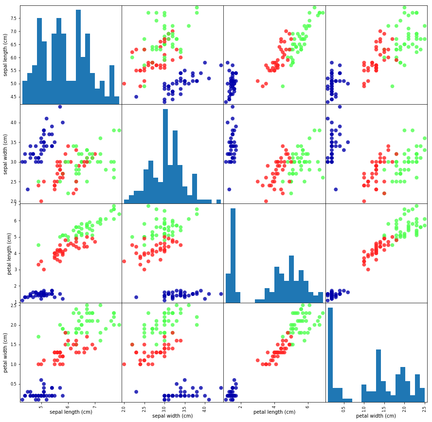

```python
from pandas.plotting import scatter_matrix
iris_dataframe = pd.DataFrame(X_train, columns=iris_dataset.feature_names)
scatter_matrix(iris_dataframe, c=y_train, figsize=(15,15), marker = 'o',
                          hist_kwds={'bins':20}, s=60, alpha=.8, cmap = mglearn.cm3)
```

## 4) 첫번째 머신러닝 모델 : k-최근접 이웃 알고리즘

- k-최근접이웃(K-Nearest Neighbors) 분류기 새로운 데이터 포인트에 대한 예측이 필요하면 알고리즘은 새 데이터 포인트에서 가장 가까운 훈련 데이터 포인트를 찾습니다.  
  찾은 훈련 데이터의 레이블을 새 데이터 포인트의 레이블로 지정.  
  k-최근접 이웃 알고리즘에서 k는 가장 가까운 이웃 '하나'가 아니라 훈련데이터에서 가장 가까운 'k'개의 이웃을 찾는다는 의미.  
  이 이웃들의 클래스 중 빈도가 가장 높은 클래스를 예측값으로 사용.

```python
from sklearn.neighbors import KNeighborsClassifier
knn = KNeighborsClassifier(n_neighbors=1)
# knn객체는 훈련데이터로 모델을 만들고 새로운 데이터 포인트에 대해 예측하는 알고리즘을 캡슐화 했음.
```

scikit-learn의 모든 머신러닝 모델은 Estimator라는 파이썬 클래스로 각각 구현되어 있습니다. k-최근접 이웃 분류 알고리즘은 neighbors 모듈 아래  
KNeighborsClassifier 클래스에 구현 되어있습니다.  
모델을 사용하려면 클래스로부터 개체를 만들어야 합니다.  
모델에 필요한 매개변수를 넣습니다.  
KNeighborsClassifier에서 가장 중요한 매개 변수는 이웃의 갯수!

```python
#훈련 데이터셋으로부터 모델을 만들기 위해 knn객체의 fit메서드 사용
knn.fit(X_train,y_train)
```

```
KNeighborsClassifier(algorithm='auto', leaf_size=30, metric='minkowski',
                     metric_params=None, n_jobs=None, n_neighbors=1, p=2,
                     weights='uniform')
```

fit메서드는 knn객체 자체를 변형 시켜서 반환을 시킴.  
knn객체가 문자열 형태로 출력되는데,  
객체를 생성하기 위한 매개 변수들을 확인 할 수 잇음.  
매개변수에 대한 자세한 내용들은 다음에...

## 5) 예측하기

Q. 꽃받침의 길이가 5cm, 폭이 2.9cm,  
꽃잎의 길이가 1cm, 폭이 0.2cm 인 붓꽃의 품종은?

```python
X_new = np.array([[5, 2.9, 1, 0.2]])
print("X_new.shape : ", X_new.shape )
```

```
X_new.shape :  (1, 4)
```

```python
prediction = knn.predict(X_new)
print("예측 : ", prediction)
print("예측한 타깃의 이름 : ", iris_dataset['target_names'][prediction])
```

```
예측 :  [0]
예측한 타깃의 이름 :  ['setosa']
```

예측의 클래스는 0 이고  
예측한 품종의 이름은 setosa

## 6) 모델 평가하기

```python
y_pred = knn.predict(X_test)
print("테스트 세트에 대한 예측 값 :\n ", y_pred)
```

```
테스트 세트에 대한 예측 값 :
  [2 1 0 2 0 2 0 1 1 1 2 1 1 1 1 0 1 1 0 0 2 1 0 0 2 0 0 1 1 0 2 1 0 2 2 1 0
 2]
```

```python
print("테스트 세트의 정확도 : {:.2f}".format(np.mean(y_pred == y_test)))
print("테스트 세트의 정확도 : {:.2f}".format(knn.score(X_test, y_test)))
```

```
테스트 세트의 정확도 : 0.97
테스트 세트의 정확도 : 0.97
```

# ※ 정리 하기 ※

- 머신러닝과 머신러닝 어플리케이션 소개
- 지도학습 비지도학습 차이
- 사용할 도구
- 붓꽃의 품종 예측 작업 (전문가가 정확한 품종으로 구분해 놓은 데이터 셋 사용) = 지도학습
- 분류 문제에서는 각 품종을 **클래스**  
  개별 붓꽃의 품종을 **레이블**이라고 함.
- 붓꽃데이터 셋은 두개의 Numpy 배열로 이루어짐.
  - 하나는 데이터를 담고 있음. X표시
  - 하나는 정확한 혹은 기대하는 출력. y표시 배열X는 2차원 배열로,  
    각 **데이터 포인트**는 행으로  
    각 **특성**은 열 하나로 이루어짐.  
    배열 y는 1차원 배열로 각 샘플의 클래스 레이블에 해당하는 0~2사이의 정수를 담음.

knn(k-최근접 이웃 분류 알고리즘)은 새 데이터 포인트를 예측하기 위해 훈련 데이터에서 가장 가까운 이웃을 선택함.  
KNeighborsClassifier 클래스에 구현되어 있으며 모델을 만드는 것은 물론 예측하는 기능도 제공.

n_neighbors라는 매개변수를 지정하여 클래스 객체를 만들었고,  
fit메서드를 호출해 모델을 만들었고, 모델의 정확도는 score메서드로 모델을 평가함.

```python
X_train, X_test, y_train, y_test = train_test_split(
    iris_dataset['data'], iris_dataset['target'], random_state= 0)
knn = KNeighborsClassifier(n_neighbors=2)
knn.fit(X_train, y_train)

print("테스트 세트의 정확도 : {:.2f}".format(knn.score(X_test, y_test)))
```

```
테스트 세트의 정확도 : 0.97
```